# IE48B - Project

Alihan Zer - İrem Öztürk

23 01 2022

# Introduction

## Problem Definition

The aim of this project is making predictions of imbalance for Turkish Electricity Market. Predicting process directions is important for the intraday market. This is necessary because day-ahead forecasts are rarely perfect due to changes in weather conditions, special events etc. So, demand/production ratio is not constant which results in excess demand or supply surplus. At either case, intraday market may help companies to resolve “imbalance” problems. However, this is not always the case. When imbalance problem occurs, EPİAŞ penalizes the imbalance. To avoid that predicting intraday imbalance is crucial.

## Model Approach

To design the model, bulk imbalance data from EPİAŞ is provided. Model is based on net imbalance data which is total of upRegulationsDelivered and the downRegulationDelivered information.

Explainable boosted linear regression is used with additional factors like temperature, wind speed and the percentage of cloud cover. According to forecasted values, process direction is found. After improving the model, it is compared with two baselines, discussed in following sections.

## Data Visualization

To start with, the data needed to be read and visualized. As stated previously, the “bulk_imbalance” data set was used. There were a couple of meaningful features in this data sets; however, additional feature generation was required to perform upcoming analyzes.

Since this data was time dependent, several time related feautures needed to be added, such as trend, days, months, and the date.

```r
bulk_imbalance = fread("bulk_imbalance.csv")
bulk_imbalance = data.table(bulk_imbalance)
bulk_imbalance[,trend:=1:.N]
bulk_imbalance[,datetime:=ymd(date) + dhours(hour)]
bulk_imbalance[,w_day:=as.character(wday(datetime))]
bulk_imbalance[,mon:=as.character(month(datetime))]
```

```r
bulk_table = bulk_imbalance[,.(datetime, net, upRegulationDelivered, downRegulationDelivered, system_direction)]
head(bulk_table, 24)
```

```
##                datetime       net upRegulationDelivered downRegulationDelivered
##  1: 2019-01-01 00:00:00 -1934.795                 0.000               -1934.795
##  2: 2019-01-01 01:00:00  -750.866                 0.000                -750.866
##  3: 2019-01-01 02:00:00  -982.767                 0.000                -982.767
##  4: 2019-01-01 03:00:00  -764.620                 0.000                -764.620
##  5: 2019-01-01 04:00:00 -1233.289                 0.000               -1233.289
##  6: 2019-01-01 05:00:00 -1469.061                 0.000               -1469.061
##  7: 2019-01-01 06:00:00 -1444.749                 0.000               -1444.749
##  8: 2019-01-01 07:00:00 -1339.938                 0.000               -1339.938
##  9: 2019-01-01 08:00:00 -1884.543                 0.000               -1884.543
## 10: 2019-01-01 09:00:00 -2178.792                 0.000               -2178.792
## 11: 2019-01-01 10:00:00 -2036.002                41.177               -2077.179
## 12: 2019-01-01 11:00:00 -1647.966                 0.000               -1647.966
## 13: 2019-01-01 12:00:00  -855.563                 0.000                -855.563
## 14: 2019-01-01 13:00:00   -78.651                 0.000                 -78.651
```

[output cut: 37 more lines]

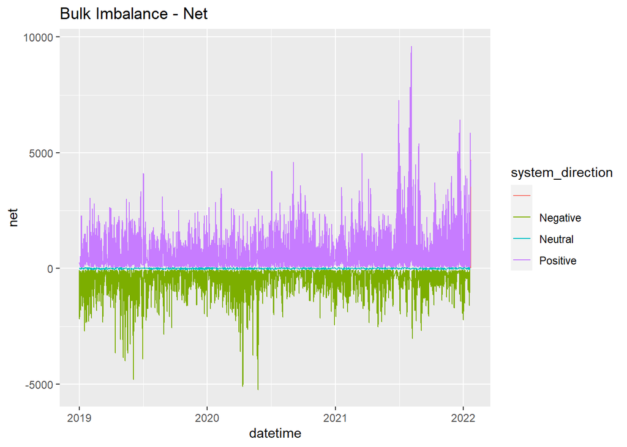

```r
ggplot(bulk_imbalance, aes(datetime, net, color = system_direction)) + geom_line() + ggtitle(label = "Bulk Imbalance - Net")
```

# Models

## Model 1

For the first model, newly added features were used in the linear regression model.

```r
lm_base <- lm(net~trend+ w_day + mon + as.factor(hour), bulk_imbalance)
summary(lm_base)
```

```
##
## Call:
## lm(formula = net ~ trend + w_day + mon + as.factor(hour), data = bulk_imbalance)
##
## Residuals:
##     Min      1Q  Median      3Q     Max
## -5490.3  -571.8   -29.4   515.7  8501.2
##
## Coefficients:
##                     Estimate Std. Error t value Pr(>|t|)
## (Intercept)       -6.312e+02  3.931e+01 -16.059  < 2e-16 ***
## trend              2.662e-02  8.207e-04  32.443  < 2e-16 ***
## w_day2             3.223e+02  2.285e+01  14.106  < 2e-16 ***
## w_day3             3.932e+02  2.282e+01  17.235  < 2e-16 ***
## w_day4             3.666e+02  2.282e+01  16.068  < 2e-16 ***
## w_day5             4.115e+02  2.282e+01  18.034  < 2e-16 ***
## w_day6             3.554e+02  2.282e+01  15.576  < 2e-16 ***
## w_day7             2.224e+02  2.282e+01   9.749  < 2e-16 ***
## mon10              2.132e+01  2.853e+01   0.747 0.454955
## mon11              1.221e+01  2.886e+01   0.423 0.672276
## mon12              5.463e+00  2.867e+01   0.191 0.848895
## mon2               6.498e+01  2.922e+01   2.224 0.026172 *
## mon3               2.050e-01  2.846e+01   0.007 0.994252
## mon4              -1.425e+02  2.869e+01  -4.967 6.83e-07 ***
## mon5              -6.586e+01  2.842e+01  -2.318 0.020466 *
## mon6               1.310e+02  2.868e+01   4.568 4.94e-06 ***
## mon7               3.657e+02  2.842e+01  12.866  < 2e-16 ***
## mon8               3.779e+02  2.845e+01  13.282  < 2e-16 ***
## mon9              -7.939e+01  2.875e+01  -2.762 0.005756 **
## as.factor(hour)1   1.539e+02  4.221e+01   3.645 0.000267 ***
## as.factor(hour)2   8.692e+01  4.221e+01   2.059 0.039503 *
## as.factor(hour)3   3.138e+01  4.221e+01   0.743 0.457214
## as.factor(hour)4  -2.881e+01  4.221e+01  -0.683 0.494864
## as.factor(hour)5  -5.253e+01  4.221e+01  -1.244 0.213337
## as.factor(hour)6  -1.514e+02  4.221e+01  -3.588 0.000334 ***
## as.factor(hour)7  -1.187e+02  4.221e+01  -2.813 0.004918 **
## as.factor(hour)8   5.466e+01  4.221e+01   1.295 0.195380
## as.factor(hour)9   3.095e+02  4.221e+01   7.332 2.33e-13 ***
## as.factor(hour)10  2.894e+02  4.221e+01   6.855 7.30e-12 ***
## as.factor(hour)11  4.222e+02  4.221e+01  10.002  < 2e-16 ***
## as.factor(hour)12  2.238e+02  4.221e+01   5.301 1.16e-07 ***
## as.factor(hour)13  1.539e+02  4.221e+01   3.645 0.000268 ***
## as.factor(hour)14  4.177e+02  4.221e+01   9.896  < 2e-16 ***
## as.factor(hour)15  4.094e+02  4.221e+01   9.698  < 2e-16 ***
## as.factor(hour)16  3.466e+02  4.221e+01   8.211 2.29e-16 ***
## as.factor(hour)17  4.359e+02  4.221e+01  10.326  < 2e-16 ***
## as.factor(hour)18  4.189e+02  4.221e+01   9.924  < 2e-16 ***
## as.factor(hour)19  3.918e+02  4.221e+01   9.280  < 2e-16 ***
## as.factor(hour)20  3.813e+02  4.221e+01   9.034  < 2e-16 ***
## as.factor(hour)21  4.066e+02  4.221e+01   9.632  < 2e-16 ***
## as.factor(hour)22  2.931e+02  4.221e+01   6.944 3.89e-12 ***
## as.factor(hour)23  2.203e+02  4.221e+01   5.219 1.81e-07 ***
## ---
## Signif. codes:  0 '***' 0.001 '**' 0.01 '*' 0.05 '.' 0.1 ' ' 1
##
## Residual standard error: 998 on 26790 degrees of freedom
## Multiple R-squared:  0.1089, Adjusted R-squared:  0.1076
## F-statistic: 79.89 on 41 and 26790 DF,  p-value: < 2.2e-16
```

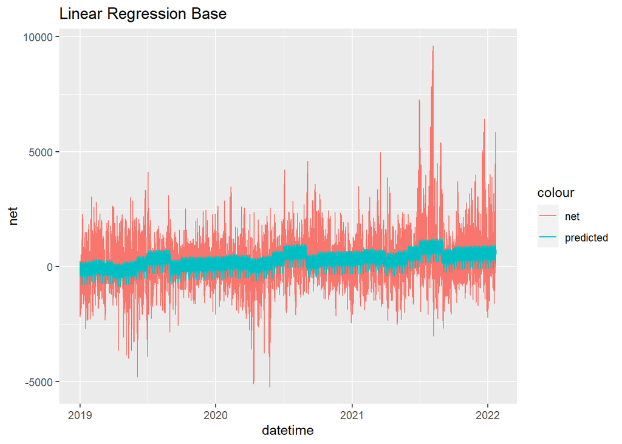

```r
bulk_imbalance[, predicted:= ((predict(lm_base, bulk_imbalance)))]
ggplot(data = bulk_imbalance, aes(x=datetime, y=net)) + geom_line(aes(y = net, color = 'net'))+geom_line(aes(y=predicted, color = 'predicted')) + ggtitle("Linear Regression Base")
```

This plot shows the predictions and the actual values for a randomly selected day.

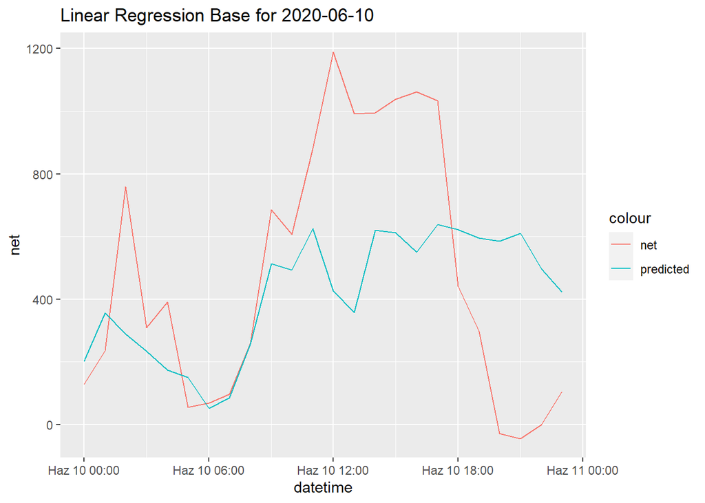

```r
ggplot(data = bulk_imbalance[date == '2020-06-10',], aes(x=datetime, y=net)) + geom_line(aes(y = net, color = 'net'))+geom_line(aes(y=predicted, color = 'predicted'))+ ggtitle("Linear Regression Base for 2020-06-10")
```

## Model 2

For this model, the weather information was used. More specifically, the surface temperature, cloud cover, and the wind speed was used. The reason for these selections is that, the surface temperature may affect the demand. The cloud cover and the wind speed may affect the electricity production. For the sake of simplicity, only the coordinates lat = 36.5 and lon = 32.5 were selected.

```r
weather = fread("2022-01-22_weather.csv")
tempweather = weather[variable == 'TMP_2.m.above.ground',]
tempweather = tempweather[date>="2019-01-01",]
tempweather = tempweather[date<="2022-01-22",]
tempweather = tempweather[lat == 36.5,]
tempweather = tempweather[lon == 32.5,]

tail(tempweather, 24)
```

```
##           date hour  lat  lon             variable  value
##  1: 2022-01-22    0 36.5 32.5 TMP_2.m.above.ground -1.561
##  2: 2022-01-22    1 36.5 32.5 TMP_2.m.above.ground -0.915
##  3: 2022-01-22    2 36.5 32.5 TMP_2.m.above.ground -0.612
##  4: 2022-01-22    3 36.5 32.5 TMP_2.m.above.ground -0.527
##  5: 2022-01-22    4 36.5 32.5 TMP_2.m.above.ground -0.312
##  6: 2022-01-22    5 36.5 32.5 TMP_2.m.above.ground -0.216
##  7: 2022-01-22    6 36.5 32.5 TMP_2.m.above.ground -0.344
##  8: 2022-01-22    7 36.5 32.5 TMP_2.m.above.ground -0.456
##  9: 2022-01-22    8 36.5 32.5 TMP_2.m.above.ground -0.824
## 10: 2022-01-22    9 36.5 32.5 TMP_2.m.above.ground -0.765
## 11: 2022-01-22   10 36.5 32.5 TMP_2.m.above.ground -0.385
## 12: 2022-01-22   11 36.5 32.5 TMP_2.m.above.ground -0.115
## 13: 2022-01-22   12 36.5 32.5 TMP_2.m.above.ground -0.201
## 14: 2022-01-22   13 36.5 32.5 TMP_2.m.above.ground  0.574
## 15: 2022-01-22   14 36.5 32.5 TMP_2.m.above.ground  0.588
## 16: 2022-01-22   15 36.5 32.5 TMP_2.m.above.ground  0.626
## 17: 2022-01-22   16 36.5 32.5 TMP_2.m.above.ground  0.311
## 18: 2022-01-22   17 36.5 32.5 TMP_2.m.above.ground  0.664
## 19: 2022-01-22   18 36.5 32.5 TMP_2.m.above.ground  1.327
## 20: 2022-01-22   19 36.5 32.5 TMP_2.m.above.ground  0.738
## 21: 2022-01-22   20 36.5 32.5 TMP_2.m.above.ground  0.930
## 22: 2022-01-22   21 36.5 32.5 TMP_2.m.above.ground  0.874
## 23: 2022-01-22   22 36.5 32.5 TMP_2.m.above.ground  1.196
## 24: 2022-01-22   23 36.5 32.5 TMP_2.m.above.ground  1.489
##           date hour  lat  lon             variable  value
```

```r
tempweather1 = weather[variable == 'TCDC_low.cloud.layer',]
tempweather1 = tempweather1[date>="2019-01-01",]
tempweather1 = tempweather1[date<="2022-01-22",]
tempweather1 = tempweather1[lat == 36.5,]
tempweather1 = tempweather1[lon == 32.5,]
tail(tempweather1, 24)
```

```
##           date hour  lat  lon             variable value
##  1: 2022-01-22    0 36.5 32.5 TCDC_low.cloud.layer  99.1
##  2: 2022-01-22    1 36.5 32.5 TCDC_low.cloud.layer  99.3
##  3: 2022-01-22    2 36.5 32.5 TCDC_low.cloud.layer  99.3
##  4: 2022-01-22    3 36.5 32.5 TCDC_low.cloud.layer  99.4
##  5: 2022-01-22    4 36.5 32.5 TCDC_low.cloud.layer 100.0
##  6: 2022-01-22    5 36.5 32.5 TCDC_low.cloud.layer 100.0
##  7: 2022-01-22    6 36.5 32.5 TCDC_low.cloud.layer 100.0
##  8: 2022-01-22    7 36.5 32.5 TCDC_low.cloud.layer 100.0
##  9: 2022-01-22    8 36.5 32.5 TCDC_low.cloud.layer 100.0
## 10: 2022-01-22    9 36.5 32.5 TCDC_low.cloud.layer 100.0
## 11: 2022-01-22   10 36.5 32.5 TCDC_low.cloud.layer 100.0
## 12: 2022-01-22   11 36.5 32.5 TCDC_low.cloud.layer 100.0
## 13: 2022-01-22   12 36.5 32.5 TCDC_low.cloud.layer 100.0
## 14: 2022-01-22   13 36.5 32.5 TCDC_low.cloud.layer 100.0
## 15: 2022-01-22   14 36.5 32.5 TCDC_low.cloud.layer 100.0
## 16: 2022-01-22   15 36.5 32.5 TCDC_low.cloud.layer 100.0
## 17: 2022-01-22   16 36.5 32.5 TCDC_low.cloud.layer 100.0
## 18: 2022-01-22   17 36.5 32.5 TCDC_low.cloud.layer 100.0
## 19: 2022-01-22   18 36.5 32.5 TCDC_low.cloud.layer 100.0
## 20: 2022-01-22   19 36.5 32.5 TCDC_low.cloud.layer 100.0
## 21: 2022-01-22   20 36.5 32.5 TCDC_low.cloud.layer 100.0
## 22: 2022-01-22   21 36.5 32.5 TCDC_low.cloud.layer 100.0
## 23: 2022-01-22   22 36.5 32.5 TCDC_low.cloud.layer 100.0
## 24: 2022-01-22   23 36.5 32.5 TCDC_low.cloud.layer 100.0
##           date hour  lat  lon             variable value
```

```r
tempweather2 = weather[variable == 'ws_10m',]
tempweather2 = tempweather2[date>="2019-01-01",]
tempweather2 = tempweather2[date<="2022-01-22",]
tempweather2 = tempweather2[lat == 36.5,]
tempweather2 = tempweather2[lon == 32.5,]
tail(tempweather2, 24)
```

```
##           date hour  lat  lon variable    value
##  1: 2022-01-22    0 36.5 32.5   ws_10m 2.558151
##  2: 2022-01-22    1 36.5 32.5   ws_10m 2.262322
##  3: 2022-01-22    2 36.5 32.5   ws_10m 3.045144
##  4: 2022-01-22    3 36.5 32.5   ws_10m 2.816556
##  5: 2022-01-22    4 36.5 32.5   ws_10m 3.351368
##  6: 2022-01-22    5 36.5 32.5   ws_10m 3.582647
##  7: 2022-01-22    6 36.5 32.5   ws_10m 3.602678
##  8: 2022-01-22    7 36.5 32.5   ws_10m 3.449708
##  9: 2022-01-22    8 36.5 32.5   ws_10m 3.406647
## 10: 2022-01-22    9 36.5 32.5   ws_10m 3.461583
## 11: 2022-01-22   10 36.5 32.5   ws_10m 3.892411
## 12: 2022-01-22   11 36.5 32.5   ws_10m 3.594445
## 13: 2022-01-22   12 36.5 32.5   ws_10m 4.108635
## 14: 2022-01-22   13 36.5 32.5   ws_10m 4.668157
## 15: 2022-01-22   14 36.5 32.5   ws_10m 4.634487
## 16: 2022-01-22   15 36.5 32.5   ws_10m 5.037978
## 17: 2022-01-22   16 36.5 32.5   ws_10m 5.843327
## 18: 2022-01-22   17 36.5 32.5   ws_10m 4.892361
## 19: 2022-01-22   18 36.5 32.5   ws_10m 6.767539
## 20: 2022-01-22   19 36.5 32.5   ws_10m 6.044384
## 21: 2022-01-22   20 36.5 32.5   ws_10m 6.553450
## 22: 2022-01-22   21 36.5 32.5   ws_10m 6.839752
## 23: 2022-01-22   22 36.5 32.5   ws_10m 6.422505
## 24: 2022-01-22   23 36.5 32.5   ws_10m 8.499578
##           date hour  lat  lon variable    value
```

```r
bulk_imbalance$temperature = tempweather$value
bulk_imbalance$cloud = tempweather1$value
bulk_imbalance$wind = tempweather2$value

lm_base2 <- lm(net~trend+ w_day + mon + as.factor(hour) + temperature + cloud + wind, bulk_imbalance)
summary(lm_base2)
```

```
##
## Call:
## lm(formula = net ~ trend + w_day + mon + as.factor(hour) + temperature +
##     cloud + wind, data = bulk_imbalance)
##
## Residuals:
##     Min      1Q  Median      3Q     Max
## -5498.4  -570.6   -25.5   516.7  8476.8
##
## Coefficients:
##                     Estimate Std. Error t value Pr(>|t|)
## (Intercept)       -7.012e+02  4.114e+01 -17.044  < 2e-16 ***
## trend              2.642e-02  8.281e-04  31.901  < 2e-16 ***
## w_day2             3.226e+02  2.282e+01  14.137  < 2e-16 ***
## w_day3             3.782e+02  2.285e+01  16.552  < 2e-16 ***
## w_day4             3.588e+02  2.280e+01  15.736  < 2e-16 ***
## w_day5             3.992e+02  2.284e+01  17.480  < 2e-16 ***
## w_day6             3.459e+02  2.283e+01  15.151  < 2e-16 ***
## w_day7             2.216e+02  2.278e+01   9.728  < 2e-16 ***
## mon10             -1.046e+01  3.735e+01  -0.280 0.779511
## mon11              2.494e+00  3.253e+01   0.077 0.938886
## mon12             -5.197e+00  2.938e+01  -0.177 0.859612
## mon2               7.840e+01  2.937e+01   2.669 0.007610 **
## mon3               3.366e+00  2.916e+01   0.115 0.908106
## mon4              -1.633e+02  3.249e+01  -5.027 5.02e-07 ***
## mon5              -1.137e+02  3.935e+01  -2.889 0.003867 **
## mon6               7.247e+01  4.201e+01   1.725 0.084497 .
## mon7               2.735e+02  4.739e+01   5.772 7.94e-09 ***
## mon8               2.825e+02  4.760e+01   5.935 2.98e-09 ***
## mon9              -1.419e+02  4.322e+01  -3.283 0.001027 **
## as.factor(hour)1   1.554e+02  4.215e+01   3.688 0.000226 ***
## as.factor(hour)2   8.939e+01  4.215e+01   2.120 0.033974 *
## as.factor(hour)3   3.467e+01  4.216e+01   0.822 0.410872
## as.factor(hour)4  -2.550e+01  4.218e+01  -0.605 0.545401
## as.factor(hour)5  -4.819e+01  4.220e+01  -1.142 0.253408
## as.factor(hour)6  -1.470e+02  4.221e+01  -3.484 0.000495 ***
## as.factor(hour)7  -1.210e+02  4.217e+01  -2.870 0.004111 **
## as.factor(hour)8   3.965e+01  4.225e+01   0.939 0.347988
## as.factor(hour)9   2.811e+02  4.259e+01   6.599 4.21e-11 ***
## as.factor(hour)10  2.484e+02  4.306e+01   5.770 8.02e-09 ***
## as.factor(hour)11  3.707e+02  4.352e+01   8.519  < 2e-16 ***
## as.factor(hour)12  1.614e+02  4.398e+01   3.670 0.000243 ***
## as.factor(hour)13  8.327e+01  4.428e+01   1.880 0.060071 .
## as.factor(hour)14  3.417e+02  4.443e+01   7.691 1.52e-14 ***
## as.factor(hour)15  3.323e+02  4.436e+01   7.491 7.06e-14 ***
## as.factor(hour)16  2.648e+02  4.413e+01   6.000 1.99e-09 ***
## as.factor(hour)17  3.651e+02  4.362e+01   8.371  < 2e-16 ***
## as.factor(hour)18  3.655e+02  4.295e+01   8.512  < 2e-16 ***
## as.factor(hour)19  3.565e+02  4.248e+01   8.393  < 2e-16 ***
## as.factor(hour)20  3.621e+02  4.224e+01   8.572  < 2e-16 ***
## as.factor(hour)21  3.928e+02  4.220e+01   9.307  < 2e-16 ***
## as.factor(hour)22  2.894e+02  4.216e+01   6.864 6.84e-12 ***
## as.factor(hour)23  2.185e+02  4.215e+01   5.183 2.20e-07 ***
## temperature        7.507e+00  1.786e+00   4.204 2.63e-05 ***
## cloud              1.756e+00  2.228e-01   7.879 3.42e-15 ***
## wind               1.382e+01  3.976e+00   3.476 0.000510 ***
## ---
## Signif. codes:  0 '***' 0.001 '**' 0.01 '*' 0.05 '.' 0.1 ' ' 1
##
## Residual standard error: 996.5 on 26787 degrees of freedom
## Multiple R-squared:  0.1119, Adjusted R-squared:  0.1104
## F-statistic: 76.68 on 44 and 26787 DF,  p-value: < 2.2e-16
```

The weather additions were significant; however, it is far from sufficient with the adjusted R^2 = 0.1104. In order to analyze further, the autocorrelation of this data set should be examined.

## Model 3

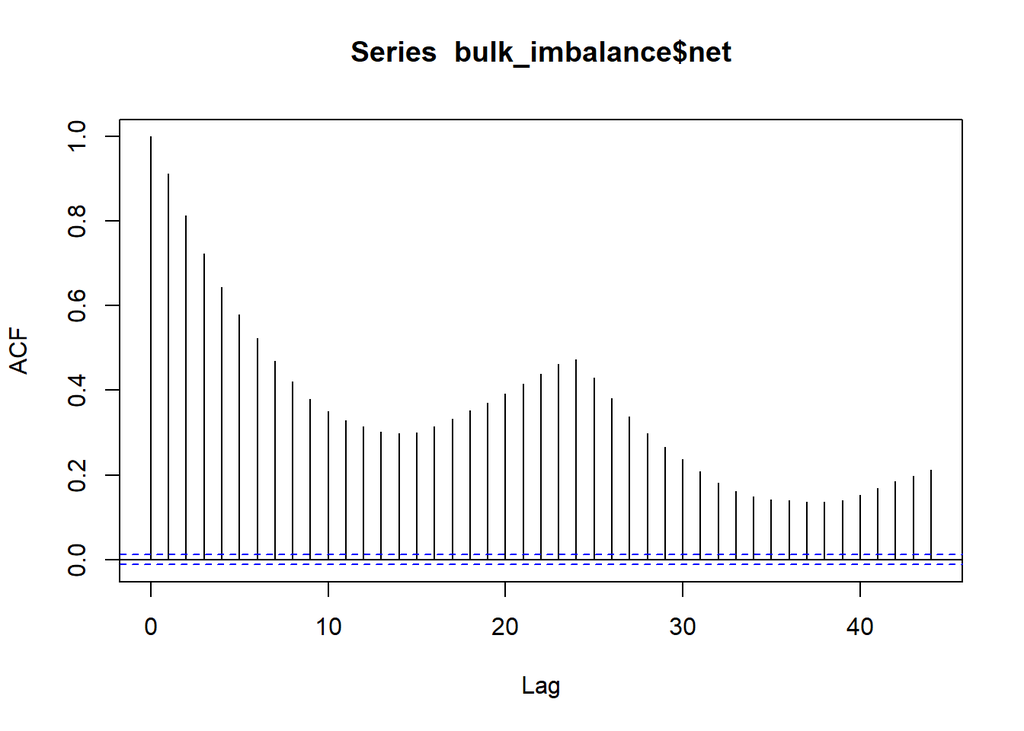

```r
acf(bulk_imbalance$net)
```

```r
shifted1 = shift(bulk_imbalance$net, 1)
shifted2 = shift(bulk_imbalance$net, 2)
shifted3 = shift(bulk_imbalance$net, 3)
shifted24 = shift(bulk_imbalance$net, 24)

bulk_imbalance$shifted1 = shifted1
bulk_imbalance$shifted2 = shifted2
bulk_imbalance$shifted3 = shifted3
bulk_imbalance$shifted24 = shifted24
```

As can be seen from the autocorrelation plot lag 1, 2, 3 and 24 can be significant for the design of the model. Also, this shows that there is daily seasonality in the data, which is expected. After adding lag 1, 2, 3 and 24, here is the summary of regression model.

```r
lm_base3 <- lm(net~trend+ w_day + mon + as.factor(hour) + temperature + cloud + wind + shifted1 + shifted2 + shifted3 + shifted24, bulk_imbalance)
summary(lm_base3)
```

```
##
## Call:
## lm(formula = net ~ trend + w_day + mon + as.factor(hour) + temperature +
##     cloud + wind + shifted1 + shifted2 + shifted3 + shifted24,
##     data = bulk_imbalance)
##
## Residuals:
##     Min      1Q  Median      3Q     Max
## -4444.3  -220.5     3.5   215.5  3042.4
##
## Coefficients:
##                     Estimate Std. Error t value Pr(>|t|)
## (Intercept)       -2.389e+02  1.705e+01 -14.013  < 2e-16 ***
## trend              1.849e-03  3.512e-04   5.264 1.42e-07 ***
## w_day2             5.259e+01  9.501e+00   5.535 3.14e-08 ***
## w_day3             4.269e+01  9.492e+00   4.498 6.89e-06 ***
## w_day4             3.641e+01  9.447e+00   3.854 0.000117 ***
## w_day5             4.394e+01  9.476e+00   4.638 3.54e-06 ***
## w_day6             2.735e+01  9.461e+00   2.891 0.003845 **
## w_day7             2.052e+01  9.413e+00   2.180 0.029297 *
## mon10             -2.768e+01  1.541e+01  -1.796 0.072532 .
## mon11             -1.605e+01  1.343e+01  -1.195 0.232026
## mon12             -1.271e+01  1.213e+01  -1.048 0.294814
## mon2               9.018e-01  1.214e+01   0.074 0.940770
## mon3              -8.999e+00  1.204e+01  -0.747 0.454994
## mon4              -3.103e+01  1.342e+01  -2.312 0.020808 *
## mon5              -3.607e+01  1.625e+01  -2.220 0.026440 *
## mon6              -2.660e+01  1.734e+01  -1.534 0.125000
## mon7              -2.342e+01  1.957e+01  -1.197 0.231492
## mon8              -2.555e+01  1.966e+01  -1.299 0.193896
## mon9              -4.670e+01  1.784e+01  -2.618 0.008848 **
## as.factor(hour)1   3.555e+02  1.743e+01  20.397  < 2e-16 ***
## as.factor(hour)2   1.114e+02  1.746e+01   6.378 1.83e-10 ***
## as.factor(hour)3   1.460e+02  1.748e+01   8.352  < 2e-16 ***
## as.factor(hour)4   1.369e+02  1.741e+01   7.860 3.99e-15 ***
## as.factor(hour)5   1.679e+02  1.743e+01   9.635  < 2e-16 ***
## as.factor(hour)6   9.047e+01  1.744e+01   5.188 2.14e-07 ***
## as.factor(hour)7   2.152e+02  1.744e+01  12.344  < 2e-16 ***
## as.factor(hour)8   3.299e+02  1.748e+01  18.868  < 2e-16 ***
## as.factor(hour)9   3.962e+02  1.771e+01  22.377  < 2e-16 ***
```

[output cut: 13 more lines]

```
## as.factor(hour)23  1.475e+02  1.742e+01   8.466  < 2e-16 ***
## temperature        2.585e+00  7.368e-01   3.508 0.000451 ***
## cloud              2.288e-01  9.207e-02   2.485 0.012947 *
## wind               1.720e+00  1.640e+00   1.049 0.294241
## shifted1           1.001e+00  6.135e-03 163.219  < 2e-16 ***
## shifted2          -1.292e-01  8.629e-03 -14.977  < 2e-16 ***
## shifted3           1.404e-03  6.077e-03   0.231 0.817319
## shifted24          5.524e-02  2.786e-03  19.823  < 2e-16 ***
## ---
## Signif. codes:  0 '***' 0.001 '**' 0.01 '*' 0.05 '.' 0.1 ' ' 1
##
## Residual standard error: 410.9 on 26759 degrees of freedom
##   (24 observations deleted due to missingness)
## Multiple R-squared:  0.8489, Adjusted R-squared:  0.8487
## F-statistic:  3133 on 48 and 26759 DF,  p-value: < 2.2e-16
```

Adjusted R^2 value, 0.8487 has improved significantly. In addition, lag 1, lag 2 and lag 24 is significant. So, after deleting the insignificant factor, regression tree may help for further feature addition.

## Model 4

### Regression Tree:

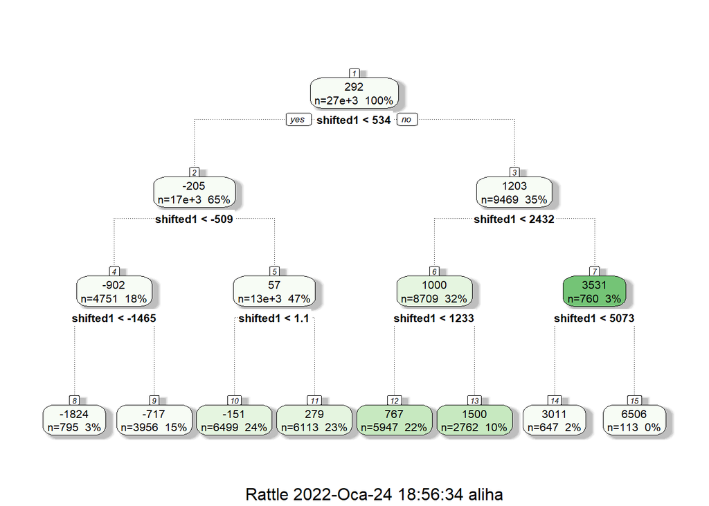

```r
fit_res_tree = rpart(net~(trend + as.factor(hour) + w_day + shifted24 + shifted1 + shifted2 + temperature + cloud), control = rpart.control(maxdepth = 3), data = bulk_imbalance)
fancyRpartPlot(fit_res_tree)
```

Box 13 is selected due to its high number of errors. Thus, new features were generated as such:

```r
bulk_imbalance[, s1 := shifted1 >= 534]
bulk_imbalance[, s2 := shifted1 < 2432]
bulk_imbalance[, s3 := shifted1 >= 1233]
```

After generating the final features, now the test data set can be obtained from the original table.

```r
test_data = head(tail(bulk_imbalance, 24),9)
bulk_imbalance = bulk_imbalance[1:(length(bulk_imbalance$net) - 24)]

lm_base4 <- lm(net~trend+ w_day + as.factor(hour) + shifted1 + shifted2 + shifted24  + s1:s2:s3 + temperature + cloud, bulk_imbalance)
summary(lm_base4)
```

```
##
## Call:
## lm(formula = net ~ trend + w_day + as.factor(hour) + shifted1 +
##     shifted2 + shifted24 + s1:s2:s3 + temperature + cloud, data = bulk_imbalance)
##
## Residuals:
##     Min      1Q  Median      3Q     Max
## -2177.9  -218.9     2.6   216.7  3082.6
##
## Coefficients: (5 not defined because of singularities)
##                           Estimate Std. Error t value Pr(>|t|)
## (Intercept)             -2.876e+02  1.819e+01 -15.806  < 2e-16 ***
## trend                    1.796e-03  3.341e-04   5.376 7.67e-08 ***
## w_day2                   5.327e+01  9.467e+00   5.627 1.85e-08 ***
## w_day3                   4.309e+01  9.453e+00   4.559 5.16e-06 ***
## w_day4                   3.516e+01  9.411e+00   3.736 0.000187 ***
## w_day5                   4.259e+01  9.437e+00   4.513 6.41e-06 ***
## w_day6                   2.569e+01  9.422e+00   2.727 0.006393 **
## w_day7                   2.284e+01  9.393e+00   2.431 0.015061 *
## as.factor(hour)1         3.515e+02  1.738e+01  20.224  < 2e-16 ***
## as.factor(hour)2         1.096e+02  1.741e+01   6.296 3.11e-10 ***
## as.factor(hour)3         1.431e+02  1.736e+01   8.244  < 2e-16 ***
## as.factor(hour)4         1.334e+02  1.736e+01   7.685 1.58e-14 ***
## as.factor(hour)5         1.634e+02  1.736e+01   9.412  < 2e-16 ***
## as.factor(hour)6         8.548e+01  1.737e+01   4.921 8.68e-07 ***
## as.factor(hour)7         2.117e+02  1.737e+01  12.188  < 2e-16 ***
## as.factor(hour)8         3.290e+02  1.740e+01  18.910  < 2e-16 ***
## as.factor(hour)9         4.027e+02  1.749e+01  23.029  < 2e-16 ***
## as.factor(hour)10        1.463e+02  1.754e+01   8.344  < 2e-16 ***
## as.factor(hour)11        3.229e+02  1.748e+01  18.472  < 2e-16 ***
## as.factor(hour)12       -3.526e+00  1.753e+01  -0.201 0.840545
## as.factor(hour)13        1.462e+02  1.752e+01   8.344  < 2e-16 ***
## as.factor(hour)14        4.398e+02  1.756e+01  25.051  < 2e-16 ***
## as.factor(hour)15        1.579e+02  1.765e+01   8.945  < 2e-16 ***
## as.factor(hour)16        1.407e+02  1.756e+01   8.008 1.21e-15 ***
## as.factor(hour)17        2.878e+02  1.753e+01  16.418  < 2e-16 ***
## as.factor(hour)18        1.764e+02  1.749e+01  10.086  < 2e-16 ***
## as.factor(hour)19        1.808e+02  1.741e+01  10.381  < 2e-16 ***
## as.factor(hour)20        2.010e+02  1.738e+01  11.561  < 2e-16 ***
## as.factor(hour)21        2.316e+02  1.738e+01  13.325  < 2e-16 ***
## as.factor(hour)22        9.944e+01  1.736e+01   5.727 1.03e-08 ***
## as.factor(hour)23        1.484e+02  1.735e+01   8.553  < 2e-16 ***
## shifted1                 1.012e+00  7.122e-03 142.046  < 2e-16 ***
## shifted2                -1.300e-01  6.029e-03 -21.565  < 2e-16 ***
## shifted24                5.502e-02  2.785e-03  19.757  < 2e-16 ***
## temperature              1.409e+00  3.391e-01   4.155 3.26e-05 ***
## cloud                    2.896e-01  8.983e-02   3.224 0.001266 **
## s1FALSE:s2FALSE:s3FALSE         NA         NA      NA       NA
## s1TRUE:s2FALSE:s3FALSE          NA         NA      NA       NA
## s1FALSE:s2TRUE:s3FALSE   5.251e+01  1.208e+01   4.347 1.39e-05 ***
## s1TRUE:s2TRUE:s3FALSE    1.333e+01  1.015e+01   1.313 0.189106
## s1FALSE:s2FALSE:s3TRUE          NA         NA      NA       NA
## s1TRUE:s2FALSE:s3TRUE    9.616e+01  1.929e+01   4.984 6.28e-07 ***
## s1FALSE:s2TRUE:s3TRUE           NA         NA      NA       NA
## s1TRUE:s2TRUE:s3TRUE            NA         NA      NA       NA
## ---
## Signif. codes:  0 '***' 0.001 '**' 0.01 '*' 0.05 '.' 0.1 ' ' 1
##
## Residual standard error: 409.5 on 26745 degrees of freedom
##   (24 observations deleted due to missingness)
## Multiple R-squared:  0.8495, Adjusted R-squared:  0.8493
## F-statistic:  3972 on 38 and 26745 DF,  p-value: < 2.2e-16
```

The adjusted R-squared value is 0.8493, which is larger compared to the previous models. These plots can be used for further visualizations regarding the success of the model

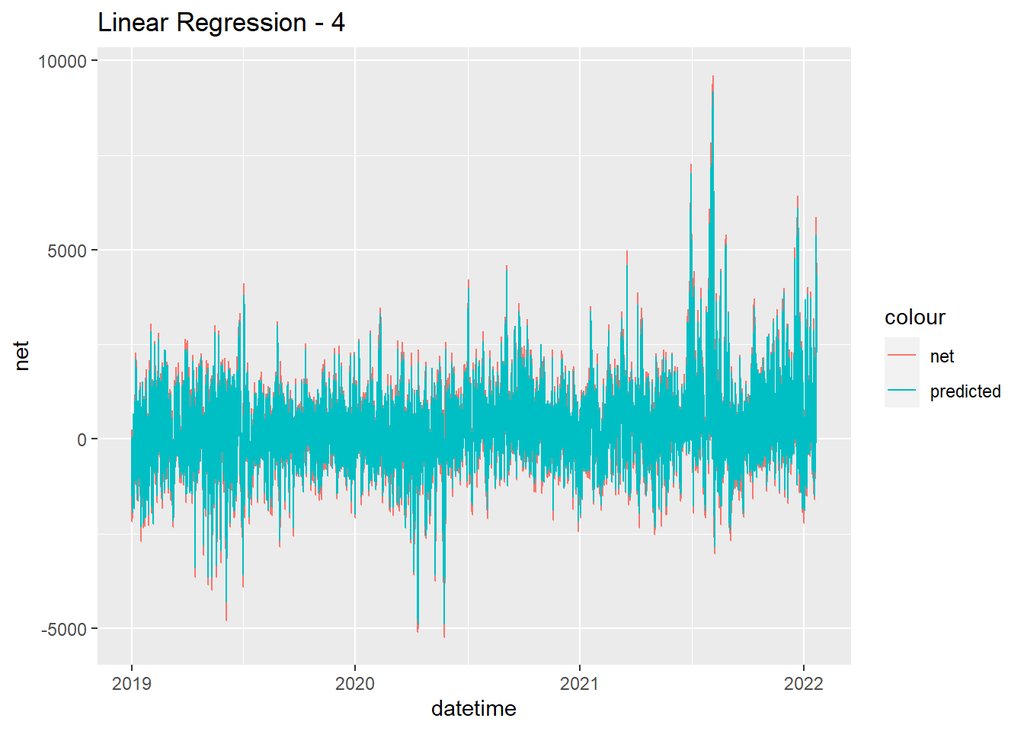

```r
bulk_imbalance[, predicted:= ((predict(lm_base4, bulk_imbalance)))]
ggplot(data = bulk_imbalance, aes(x=datetime, y=net)) + geom_line(aes(y = net, color = 'net'))+geom_line(aes(y=predicted, color = 'predicted')) + ggtitle("Linear Regression - 4")
```

This plot shows the predictions and the actual values for a randomly selected day.

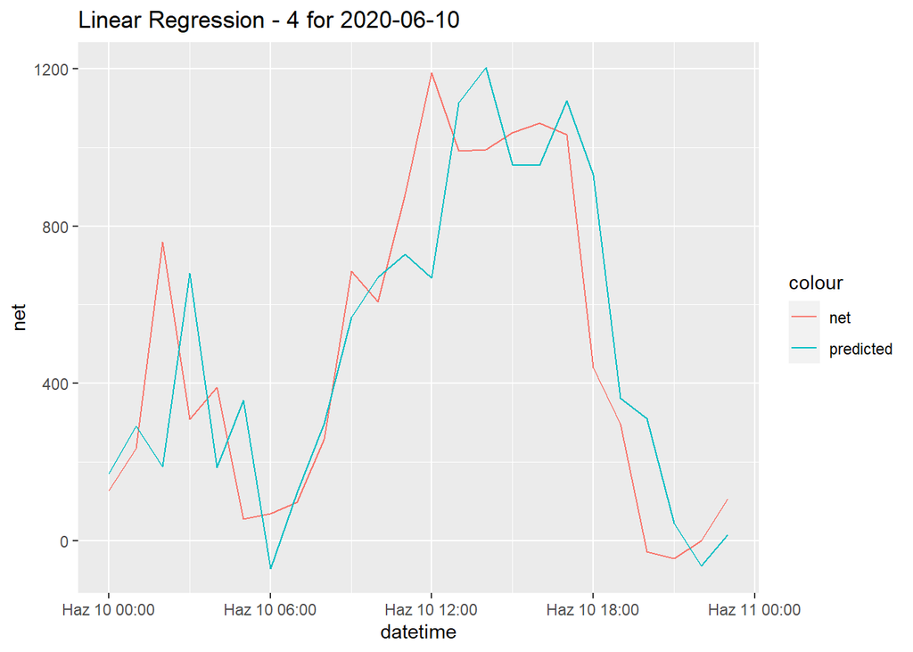

```r
ggplot(data = bulk_imbalance[date == '2020-06-10',], aes(x=datetime, y=net)) + geom_line(aes(y = net, color = 'net'))+geom_line(aes(y=predicted, color = 'predicted'))+ ggtitle("Linear Regression - 4 for 2020-06-10")
```

# Baselines

## Baseline - 1

The first baseline suggests to use the direction of the previous week, hence the lag 168.

```r
shifted168 = shift(bulk_imbalance$net, 168)
bulk_imbalance$shifted168 <- shifted168
```

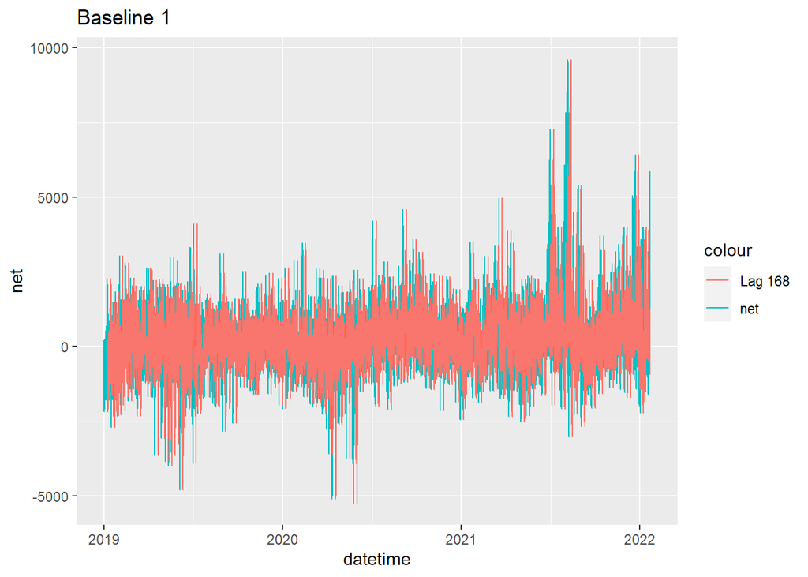

```r
ggplot(data = bulk_imbalance, aes(x=datetime, y=net)) + geom_line(aes(y = net, color = 'net'))+geom_line(aes(y=shifted168, color = 'Lag 168')) + ggtitle("Baseline 1")
```

## Baseline - 2

The second baseline suggests to use the direction of the previous day, hence the lag 24. Since lag 24 was previously added into the model, visualizing the lag 24 will be sufficient enough.

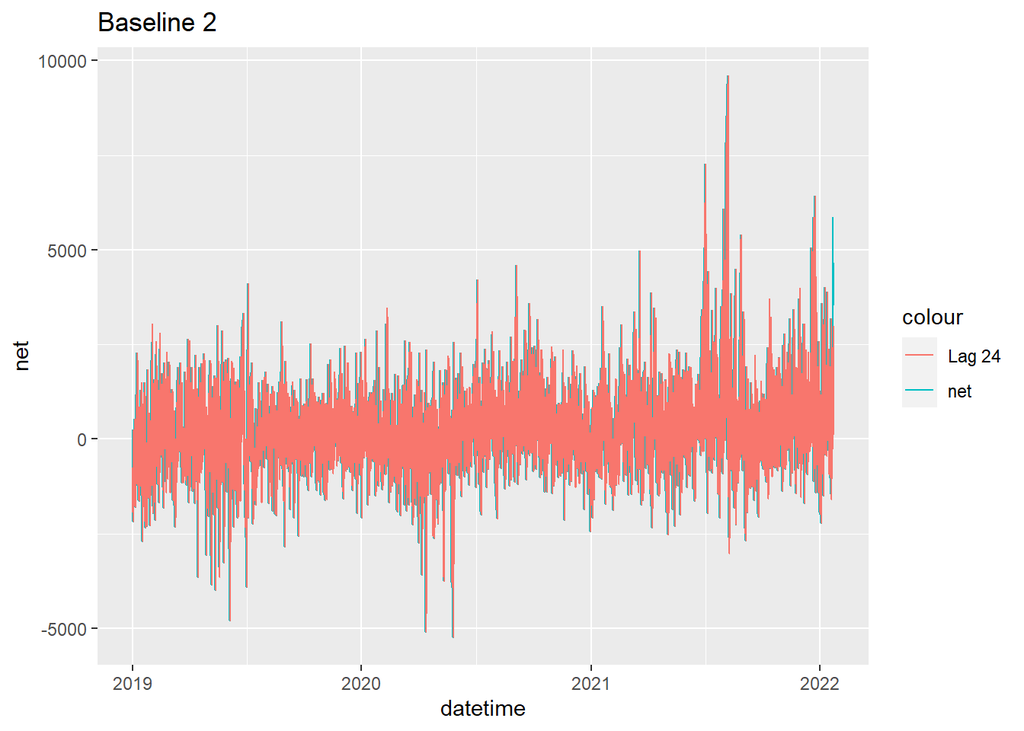

```r
ggplot(data = bulk_imbalance, aes(x=datetime, y=net)) + geom_line(aes(y = net, color = 'net'))+geom_line(aes(y=shifted24, color = 'Lag 24')) + ggtitle("Baseline 2")
```

# Conclusion

WMAPE (weighted mean absolute percentage error) was used to measure errors. The results indicate that the linear regression model performs best.

```r
wmape(bulk_imbalance$net[25:length(bulk_imbalance$net)],bulk_imbalance$predicted[25:length(bulk_imbalance$net)])
```

```
## [1] 0.3935723
```

```r
wmape(bulk_imbalance$net[25:length(bulk_imbalance$net)],bulk_imbalance$shifted24[25:length(bulk_imbalance$net)])
```

```
## [1] 1.061164
```

```r
wmape(bulk_imbalance$net[169:length(bulk_imbalance$net)],bulk_imbalance$shifted168[169:length(bulk_imbalance$net)])
```

```
## [1] 1.269351
```

# Predictions

```r
preds = predict(lm_base4, newdata = test_data)
wmape(test_data$net, preds)
```

```
## [1] 0.1195989
```

```r
test_data[preds>=50, pred_class:="Positive"]
test_data[preds<=-50, pred_class:="Negative"]
test_data[preds<50 && preds>-50, pred_class:="Neutral"]

test_data[net>=50, actual_class:="Positive"]
test_data[net<=-50, actual_class:="Negative"]
test_data[net<50 && net>-50, actual_class:="Neutral"]

results_table = test_data[,.(datetime, net, preds, actual_class, pred_class)]
results_table
```

```
##               datetime      net    preds actual_class pred_class
## 1: 2022-01-22 00:00:00 4500.204 4146.575     Positive   Positive
## 2: 2022-01-22 01:00:00 4687.520 4286.557     Positive   Positive
## 3: 2022-01-22 02:00:00 3819.368 4249.509     Positive   Positive
## 4: 2022-01-22 03:00:00 3075.214 3392.218     Positive   Positive
## 5: 2022-01-22 04:00:00 2522.163 2698.314     Positive   Positive
## 6: 2022-01-22 05:00:00 2696.979 2285.035     Positive   Positive
## 7: 2022-01-22 06:00:00 3018.599 2493.382     Positive   Positive
## 8: 2022-01-22 07:00:00 3725.378 2947.106     Positive   Positive
## 9: 2022-01-22 08:00:00 4338.125 3858.409     Positive   Positive
```

### Success rate calculation

```r
inc = 0
for(i in (1:9)){
  if(results_table$actual_class[i] == results_table$pred_class[i]){
    inc = inc + 1
  }
}
inc/9
```

```
## [1] 1
```